# Analysis of NLA17 Dissolved Gas Indicator

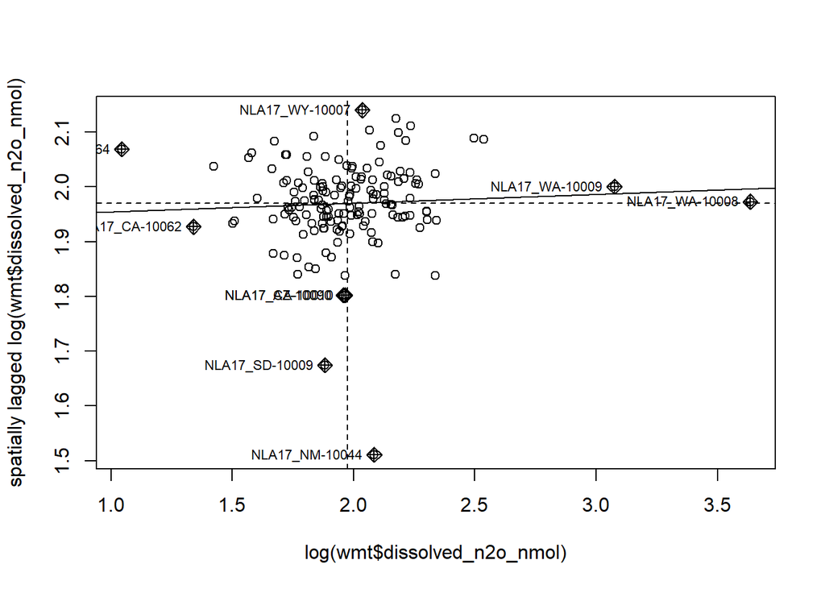

```r
moran.plot(log(wmt$dissolved_n2o_nmol), listw = dsnb1.listw, labels = wmt$site_id)
```

```r
rm(ds1coords, ds1nb1, dsnb1, dsnb1.listw, dsnb1_dist)

## XER
xer <- dg_sf1 %>% filter(wsa9 == "XER" & visit_no == 1 & sample_source == "DG")

xer_sp <- as(xer, "Spatial")
class(xer_sp)
```

```
## [1] "SpatialPointsDataFrame"
## attr(,"package")
## [1] "sp"
```

```r
# nrow(zerodist(xer_sp)) # indicates 1 pair of identical coordinates
# (zerodist(xer_sp)) # this gives the row numbers of the pair 136 & 158
# View(xer) # to view rows 136, site_id NLA17_WI-10027, & 158, NLA17_WI-10127

# Warning message from code below:
# In knearneigh(ds1coords, k = 1) : knearneigh: identical points found

ds1coords <- coordinates(xer_sp)
ds1nb1 <- knn2nb(knearneigh(ds1coords, k=1), row.names = xer_sp$site_id)
# using the k=1 object to find the minimum distance at which all sites have a distance-based neighbor
dsnb1_dist <- unlist(nbdists(ds1nb1,ds1coords))
summary(dsnb1_dist)# use max distance from summary to assign distance to create neighbors
```

```
##    Min. 1st Qu.  Median    Mean 3rd Qu.    Max.
##    7078   27462   57601   74015   89791  259278
```

```r
dsnb1 <- dnearneigh(ds1coords, d1=0, d2=259280, row.names=xer_sp$site_id, longlat=FALSE)
summary(dsnb1)
```

```
## Neighbour list object:
## Number of regions: 83
## Number of nonzero links: 750
## Percentage nonzero weights: 10.88692
## Average number of links: 9.036145
## Link number distribution:
##
##  1  2  3  4  5  6  7  8  9 10 11 12 13 14 15 16
##  6  3  5  7  3  1  1  2 13  7  5 10  5  6  4  5
## 6 least connected regions:
## NLA17_AZ-10012 NLA17_CA-10005 NLA17_NM-10001 NLA17_NM-10024 NLA17_TX-10021 NLA17_TX-10112 with 1 link
## 5 most connected regions:
## NLA17_CA-10008 NLA17_CA-10009 NLA17_CA-10012 NLA17_ID-10032 NLA17_UT-10004 with 16 links
```

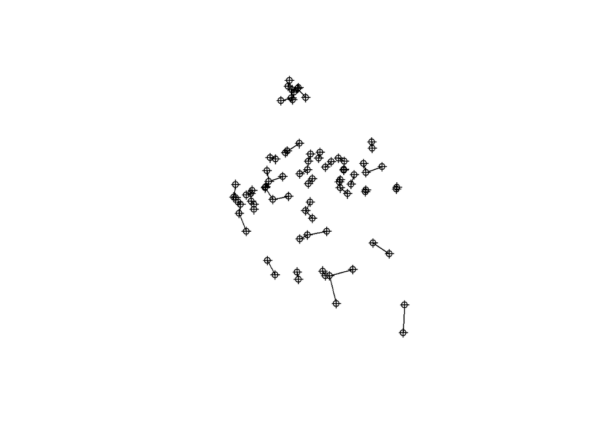

```r
plot(xer_sp)
plot(ds1nb1, ds1coords, labels = xer_sp$site_id, add = TRUE)
```

```r
dsnb1.listw <- nb2listw(dsnb1, style = "W")
summary(dsnb1.listw)
```

```
## Characteristics of weights list object:
## Neighbour list object:
## Number of regions: 83
## Number of nonzero links: 750
## Percentage nonzero weights: 10.88692
## Average number of links: 9.036145
## Link number distribution:
##
##  1  2  3  4  5  6  7  8  9 10 11 12 13 14 15 16
##  6  3  5  7  3  1  1  2 13  7  5 10  5  6  4  5
## 6 least connected regions:
## NLA17_AZ-10012 NLA17_CA-10005 NLA17_NM-10001 NLA17_NM-10024 NLA17_TX-10021 NLA17_TX-10112 with 1 link
## 5 most connected regions:
## NLA17_CA-10008 NLA17_CA-10009 NLA17_CA-10012 NLA17_ID-10032 NLA17_UT-10004 with 16 links
##
## Weights style: W
## Weights constants summary:
##    n   nn S0       S1       S2
## W 83 6889 83 31.83202 338.9354
```

```r
class(xer)
```

```
## [1] "sf"         "data.frame"
```

```r
# xer_df <- st_drop_geometry(xer)
# names(xer_df)
summary(xer$dissolved_n2o_nmol)
```

```
##    Min. 1st Qu.  Median    Mean 3rd Qu.    Max.
##   4.140   6.152   7.395   8.928   8.348  36.650
```

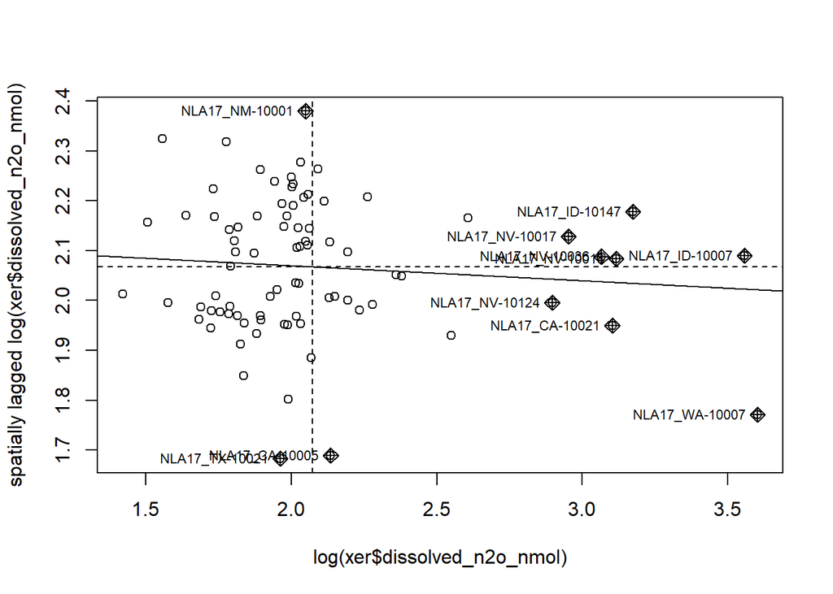

```r
moran.plot(log(xer$dissolved_n2o_nmol), listw = dsnb1.listw, labels = xer$site_id)
```

```r
rm(ds1coords, ds1nb1, dsnb1, dsnb1.listw, dsnb1_dist)

## NLA
nla <- dg_sf1 %>% filter(visit_no == 1 & sample_source == "DG")

nla_sp <- as(nla, "Spatial")
class(nla_sp)
```

```
## [1] "SpatialPointsDataFrame"
## attr(,"package")
## [1] "sp"
```

```r
nrow(zerodist(nla_sp)) # indicates 2 pairs of identical coordinates
```

```
## [1] 0
```

```r
(zerodist(nla_sp)) # this gives the row numbers of the pair (192 & 210:  NLA17_IN-10002 & NLA17_IN-10047) and the pair (1028 & 1054:  NLA17_WI-10027, & 158, NLA17_WI-10127)
```

```
##      [,1] [,2]
```

```r
# View(nla)

# Warning message from code below:
# In knearneigh(ds1coords, k = 1) : knearneigh: identical points found

ds1coords <- coordinates(nla_sp)
ds1nb1 <- knn2nb(knearneigh(ds1coords, k=1), row.names = nla_sp$site_id)
# using the k=1 object to find the minimum distance at which all sites have a distance-based neighbor
dsnb1_dist <- unlist(nbdists(ds1nb1,ds1coords))
summary(dsnb1_dist)# use max distance from summary to assign distance to create neighbors
```

```
##     Min.  1st Qu.   Median     Mean  3rd Qu.     Max.
##    926.4  14596.5  27289.6  35749.1  48891.6 259278.2
```

```r
dsnb1 <- dnearneigh(ds1coords, d1=0, d2=259280, row.names=nla_sp$site_id, longlat=FALSE)
summary(dsnb1)
```

```
## Neighbour list object:
## Number of regions: 1090
## Number of nonzero links: 40194
## Percentage nonzero weights: 3.383049
## Average number of links: 36.87523
## Link number distribution:
##
##  1  2  3  4  5  6  7  8  9 10 11 12 13 14 15 16 17 18 19 20 21 22 23 24 25
##  4  4  2  3  5  5  6 10  6 11 11 11 12 10 10 15 21 19 16 14 22 30 40 32 34
## 26 27 28 29 30 31 32 33 34 35 36 37 38 39 40 41 42 43 44 45 46 47 48 49 50
## 33 29 25 30 25 21 30 32 21 15  8 14  8 15 12 16 13 19 17 12 23  9 13 10  9
## 51 52 53 54 55 56 57 58 59 60 61 62 63 64 65 66 67 68 69 70 71 72 73 74 75
## 12  7 12 11 12 10 13  6 10 10 11 12  9 16 14 14 12 17 12 11  6 11 12  7  7
## 76 77 78
##  2  1  1
## 4 least connected regions:
## NLA17_AZ-10012 NLA17_CA-10005 NLA17_TX-10021 NLA17_TX-10112 with 1 link
## 1 most connected region:
## NLA17_MN-10019 with 78 links
```

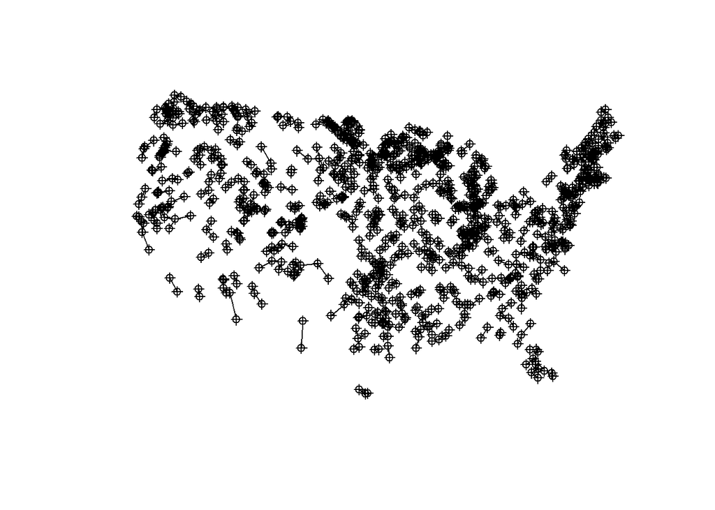

```r
plot(nla_sp)
plot(ds1nb1, ds1coords, labels = nla_sp$site_id, add = TRUE)
```

```r
dsnb1.listw <- nb2listw(dsnb1, style = "W")
summary(dsnb1.listw)
```

```
## Characteristics of weights list object:
## Neighbour list object:
## Number of regions: 1090
## Number of nonzero links: 40194
## Percentage nonzero weights: 3.383049
## Average number of links: 36.87523
## Link number distribution:
##
##  1  2  3  4  5  6  7  8  9 10 11 12 13 14 15 16 17 18 19 20 21 22 23 24 25
##  4  4  2  3  5  5  6 10  6 11 11 11 12 10 10 15 21 19 16 14 22 30 40 32 34
## 26 27 28 29 30 31 32 33 34 35 36 37 38 39 40 41 42 43 44 45 46 47 48 49 50
## 33 29 25 30 25 21 30 32 21 15  8 14  8 15 12 16 13 19 17 12 23  9 13 10  9
## 51 52 53 54 55 56 57 58 59 60 61 62 63 64 65 66 67 68 69 70 71 72 73 74 75
## 12  7 12 11 12 10 13  6 10 10 11 12  9 16 14 14 12 17 12 11  6 11 12  7  7
## 76 77 78
##  2  1  1
## 4 least connected regions:
## NLA17_AZ-10012 NLA17_CA-10005 NLA17_TX-10021 NLA17_TX-10112 with 1 link
## 1 most connected region:
## NLA17_MN-10019 with 78 links
##
## Weights style: W
## Weights constants summary:
##      n      nn   S0       S1       S2
## W 1090 1188100 1090 89.35517 4394.714
```

```r
class(nla)
```

```
## [1] "sf"         "data.frame"
```

```r
# nla_df <- st_drop_geometry(nla)
# names(nla_df)
summary(nla$dissolved_n2o_nmol)
```

```
##    Min. 1st Qu.  Median    Mean 3rd Qu.    Max.
##   1.760   6.005   6.985   8.982   8.035 242.500
```

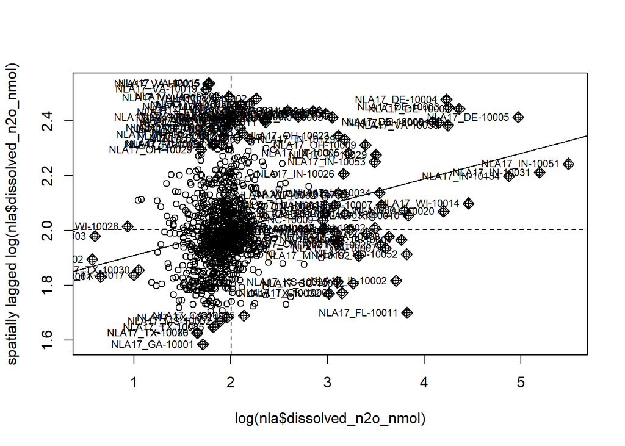

```r
moran.plot(log(nla$dissolved_n2o_nmol), listw = dsnb1.listw, labels = nla$site_id)
```

```r
rm(ds1coords, ds1nb1, dsnb1, dsnb1.listw, dsnb1_dist)
```

## 2.8 Correlograms: ncf and pgmirness packages

```r
# Much of code below is based on example comparing correlograms among packages ncf, pgmirness, and spdep described in this chapter
# https://link.springer.com/chapter/10.1007/978-3-030-01989-1_5

coords <- data.frame(longitude = dg_1$map_lon_dd, latitude = dg_1$map_lat_dd)

dg_sf1 <- st_as_sf(dg_1, coords = c("map_lon_dd", "map_lat_dd"),
                  crs = 4269) %>% # standard for lat/lon
  st_transform(5070) # project to CONUS ALBERS for plotting

st_crs(dg_sf1)
```

```
## Coordinate Reference System:
##   User input: EPSG:5070
##   wkt:
## PROJCRS["NAD83 / Conus Albers",
##     BASEGEOGCRS["NAD83",
##         DATUM["North American Datum 1983",
##             ELLIPSOID["GRS 1980",6378137,298.257222101,
##                 LENGTHUNIT["metre",1]]],
##         PRIMEM["Greenwich",0,
##             ANGLEUNIT["degree",0.0174532925199433]],
##         ID["EPSG",4269]],
##     CONVERSION["Conus Albers",
##         METHOD["Albers Equal Area",
##             ID["EPSG",9822]],
##         PARAMETER["Latitude of false origin",23,
##             ANGLEUNIT["degree",0.0174532925199433],
##             ID["EPSG",8821]],
##         PARAMETER["Longitude of false origin",-96,
##             ANGLEUNIT["degree",0.0174532925199433],
##             ID["EPSG",8822]],
##         PARAMETER["Latitude of 1st standard parallel",29.5,
##             ANGLEUNIT["degree",0.0174532925199433],
##             ID["EPSG",8823]],
##         PARAMETER["Latitude of 2nd standard parallel",45.5,
##             ANGLEUNIT["degree",0.0174532925199433],
##             ID["EPSG",8824]],
##         PARAMETER["Easting at false origin",0,
##             LENGTHUNIT["metre",1],
##             ID["EPSG",8826]],
##         PARAMETER["Northing at false origin",0,
##             LENGTHUNIT["metre",1],
##             ID["EPSG",8827]]],
##     CS[Cartesian,2],
##         AXIS["easting (X)",east,
##             ORDER[1],
##             LENGTHUNIT["metre",1]],
##         AXIS["northing (Y)",north,
##             ORDER[2],
##             LENGTHUNIT["metre",1]],
##     USAGE[
##         SCOPE["unknown"],
##         AREA["USA - CONUS - onshore"],
##         BBOX[24.41,-124.79,49.38,-66.91]],
##     ID["EPSG",5070]]
```

```r
names(dg_sf1)
```

```
##   [1] "site_id"                         "visit_no"
##   [3] "sample_source"                   "date_col"
##   [5] "n2o_ppm_gc_rpd"                  "co2_ppm_gc_rpd"
##   [7] "co2_ppm_gc_adj_rpd"              "ch4_ppm_gc_rpd"
##   [9] "dissolved_co2_rpd"               "dissolved_co2_jb_rpd"
##  [11] "dissolved_ch4_rpd"               "dissolved_n2o_rpd"
##  [13] "co2_sat_ratio_rpd"               "ch4_sat_ratio_rpd"
##  [15] "n2o_sat_ratio_rpd"               "n2o_ppm_gc"
##  [17] "co2_ppm_gc"                      "co2_ppm_gc_adj"
##  [19] "ch4_ppm_gc"                      "bp_k_pa"
##  [21] "headtemp"                        "surftemp"
##  [23] "dissolved_co2_jb"                "co2_sat_ratio"
##  [25] "ch4_sat_ratio"                   "n2o_sat_ratio"
##  [27] "co2_ppm_iso_rpd"                 "ch4_ppm_iso_rpd"
##  [29] "delta_13_ch4_rpd"                "delta_13_co2_rpd"
```

[output cut: 177 more lines]

```r
nap_visit1 <- dg_sf1 %>% filter(wsa9 == "NAP" & visit_no == 1)
class(nap_visit1)
```

```
## [1] "sf"         "data.frame"
```

```r
st_crs(nap_visit1)
```

```
## Coordinate Reference System:
##   User input: EPSG:5070
##   wkt:
## PROJCRS["NAD83 / Conus Albers",
##     BASEGEOGCRS["NAD83",
##         DATUM["North American Datum 1983",
##             ELLIPSOID["GRS 1980",6378137,298.257222101,
##                 LENGTHUNIT["metre",1]]],
##         PRIMEM["Greenwich",0,
##             ANGLEUNIT["degree",0.0174532925199433]],
##         ID["EPSG",4269]],
##     CONVERSION["Conus Albers",
##         METHOD["Albers Equal Area",
##             ID["EPSG",9822]],
##         PARAMETER["Latitude of false origin",23,
##             ANGLEUNIT["degree",0.0174532925199433],
##             ID["EPSG",8821]],
##         PARAMETER["Longitude of false origin",-96,
##             ANGLEUNIT["degree",0.0174532925199433],
##             ID["EPSG",8822]],
##         PARAMETER["Latitude of 1st standard parallel",29.5,
##             ANGLEUNIT["degree",0.0174532925199433],
##             ID["EPSG",8823]],
##         PARAMETER["Latitude of 2nd standard parallel",45.5,
##             ANGLEUNIT["degree",0.0174532925199433],
##             ID["EPSG",8824]],
##         PARAMETER["Easting at false origin",0,
##             LENGTHUNIT["metre",1],
##             ID["EPSG",8826]],
##         PARAMETER["Northing at false origin",0,
##             LENGTHUNIT["metre",1],
##             ID["EPSG",8827]]],
##     CS[Cartesian,2],
##         AXIS["easting (X)",east,
##             ORDER[1],
##             LENGTHUNIT["metre",1]],
##         AXIS["northing (Y)",north,
##             ORDER[2],
##             LENGTHUNIT["metre",1]],
##     USAGE[
##         SCOPE["unknown"],
##         AREA["USA - CONUS - onshore"],
##         BBOX[24.41,-124.79,49.38,-66.91]],
##     ID["EPSG",5070]]
```

```r
nap_sp_visit1 <- as(nap_visit1, "Spatial")
class(nap_sp_visit1)
```

```
## [1] "SpatialPointsDataFrame"
## attr(,"package")
## [1] "sp"
```

```r
# trying ncf package which uses resampling to specify number of null permutations under the null to assess significance levels.  See if significance persist after increas resamp from 100 to 1000, which is the default.
# The x-intercept in the results is the distance at which objects are no more similar than expected by chance alone across the region.
# Run on CPL as that is giving correlation greater than 1, which according to Fletcher and Fortin might be due to small number of pairs of points used in that first distance bin or to outliers.  Perhaps, cluster of high Delaware sites (n visit 1 = 5) causes the correlation to be greater than 1.
# Looks like 71 pairs of points being used.
# With a lag, or bin distance, of 50 km only go out 10 bins, 500 km, and do a Bonferroni adjustment of 0.05/10 = 0.005
names(dg_1)
```

```
##   [1] "site_id"                         "visit_no"
##   [3] "sample_source"                   "date_col"
##   [5] "n2o_ppm_gc_rpd"                  "co2_ppm_gc_rpd"
##   [7] "co2_ppm_gc_adj_rpd"              "ch4_ppm_gc_rpd"
##   [9] "dissolved_co2_rpd"               "dissolved_co2_jb_rpd"
##  [11] "dissolved_ch4_rpd"               "dissolved_n2o_rpd"
##  [13] "co2_sat_ratio_rpd"               "ch4_sat_ratio_rpd"
##  [15] "n2o_sat_ratio_rpd"               "map_lat_dd"
##  [17] "map_lon_dd"                      "n2o_ppm_gc"
##  [19] "co2_ppm_gc"                      "co2_ppm_gc_adj"
##  [21] "ch4_ppm_gc"                      "bp_k_pa"
##  [23] "headtemp"                        "surftemp"
##  [25] "dissolved_co2_jb"                "co2_sat_ratio"
##  [27] "ch4_sat_ratio"                   "n2o_sat_ratio"
##  [29] "co2_ppm_iso_rpd"                 "ch4_ppm_iso_rpd"
```

[output cut: 177 more lines]

```r
dg_cplvisit1 <- dg_1 %>% filter(wsa9 == "CPL" & visit_no == 1)
# N.B. default is resamp = 1000 so that can take 10 minutes for n =1090 sites
class(dg_cplvisit1)
```

```
## [1] "data.frame"
```

```r
correlo_n2o_ncf <- ncf::correlog(x = dg_cplvisit1$map_lon_dd, y = dg_cplvisit1$map_lat_dd, z = log(dg_cplvisit1$dissolved_n2o_nmol), increment = 50, resamp = 1000, latlon = TRUE)
```

```
## 100  of  1000
200  of  1000
300  of  1000
400  of  1000
500  of  1000
600  of  1000
700  of  1000
800  of  1000
900  of  1000
1000  of  1000
```

```r
names(correlo_n2o_ncf)
```

```
## [1] "n"             "mean.of.class" "correlation"   "x.intercept"
## [5] "p"             "call"
```

```r
#plot(correlo_n2o_ncf) # works when pgmiress commented out


# B/c returns a list of list have to access with [[]]
print(correlo_n2o_ncf[["n"]])
```

```
##   1   2   3   4   5   6   7   8   9  10  11  12  13  14  15  16  17  18
##  71 157 205 240 266 237 254 279 281 246 245 238 217 224 237 240 193 208
##  19  20  21  22  23  24  25  26  27  28  29  30  31  32  33  34  35  36
## 212 193 220 226 252 246 252 243 223 257 212 238 161 162 156 131 121 150
##  37  38  39  40  41  42  43  44  45  46  47  48  49  50  51  52  53  54
## 110 119  81  66  54  46  34  29  18  23  21  16  13  19  12   7  13   4
##  55  60  61
##   1   1   5
```

```r
print(correlo_n2o_ncf[["mean.of.class"]])
```

```
##          1          2          3          4          5          6
##   30.21935   77.03206  125.64867  175.85189  224.98428  275.16273
##          7          8          9         10         11         12
##  326.77028  374.39468  422.98699  476.10872  525.06927  574.27007
##         13         14         15         16         17         18
##  624.29221  674.78476  727.01186  775.66856  822.33392  875.34162
##         19         20         21         22         23         24
##  924.81030  976.31355 1027.78714 1074.56860 1126.09623 1174.17898
##         25         26         27         28         29         30
## 1226.24357 1274.93345 1324.83446 1375.60004 1424.69573 1473.41305
##         31         32         33         34         35         36
## 1524.08090 1571.90094 1627.18441 1671.55233 1725.55815 1775.21350
##         37         38         39         40         41         42
## 1826.51621 1876.69356 1924.72632 1976.60002 2022.57961 2072.67085
##         43         44         45         46         47         48
## 2125.31281 2170.74069 2230.35701 2279.37262 2323.13358 2379.32003
##         49         50         51         52         53         54
## 2422.51862 2478.51439 2517.61350 2574.31928 2620.91345 2668.19431
##         55         60         61
## 2705.11433 2994.97592 3023.40616
```

```r
print(correlo_n2o_ncf[["correlation"]])
```

```
##            1            2            3            4            5
##  1.470362629  0.294458853  0.206328959  0.159141830  0.187821179
##            6            7            8            9           10
##  0.032115600  0.093793497  0.115087682  0.096643147  0.040404745
##           11           12           13           14           15
## -0.004530059  0.107335625 -0.022339827  0.044667937 -0.012046726
##           16           17           18           19           20
##  0.169802740 -0.086668324  0.044158755  0.016944359 -0.054948637
##           21           22           23           24           25
## -0.061552145  0.032658809  0.030545761  0.008352118 -0.008244482
##           26           27           28           29           30
## -0.115434166  0.035923054 -0.141327962 -0.111160061 -0.090382991
##           31           32           33           34           35
## -0.123307216 -0.310553202 -0.158161199 -0.329645205 -0.163148628
##           36           37           38           39           40
## -0.180213908 -0.155058473 -0.218665449 -0.560034771 -0.552776856
##           41           42           43           44           45
##  0.059668263 -0.273153286 -0.664067628 -0.399642700 -0.089950113
##           46           47           48           49           50
## -0.276613480 -0.050542344 -0.029344378 -0.123434642 -0.909552611
##           51           52           53           54           55
## -0.911937809 -0.376210770 -0.233798571 -0.154389335  0.111839277
##           60           61
##  0.072644567 -0.211414941
```

```r
head(correlo_n2o_ncf[["mean.of.class"]])
```

```
##         1         2         3         4         5         6
##  30.21935  77.03206 125.64867 175.85189 224.98428 275.16273
```

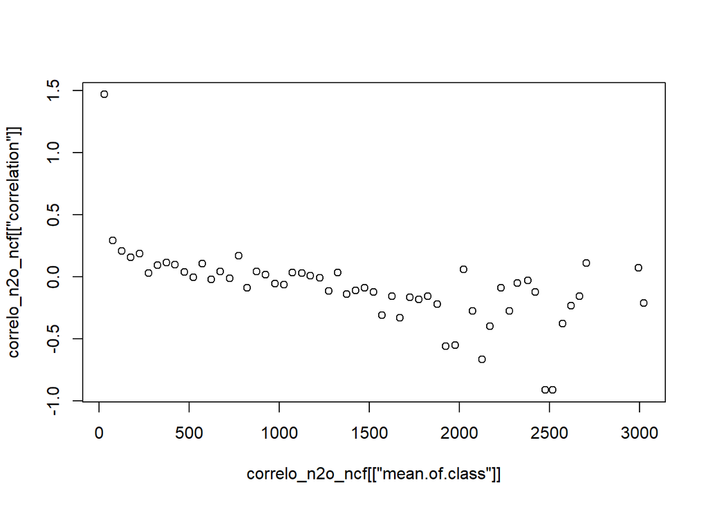

```r
plot(correlo_n2o_ncf[["mean.of.class"]], correlo_n2o_ncf[["correlation"]])
```

```r
class(correlo_n2o_ncf)
```

```
## [1] "correlog"
```

```r
#ncf::plot.correlog(correlo_n2o_ncf)

# CPL outlier check by working through all 10 pairwise removal of cluster of 5 high Delaware sites
out_cplvisit1 <- dg_1 %>% filter(wsa9 == "CPL" & visit_no == 1 & (site_id != "NLA17_DE-10003" & site_id != "NLA17_DE-10004"))

out_cplcorrelo_n2o <- ncf::correlog(x = out_cplvisit1$map_lon_dd, y = out_cplvisit1$map_lat_dd, z = log(out_cplvisit1$dissolved_n2o_nmol), increment = 50, resamp = 1000, latlon = TRUE)
```

```
## 100  of  1000
200  of  1000
300  of  1000
400  of  1000
500  of  1000
600  of  1000
700  of  1000
800  of  1000
900  of  1000
1000  of  1000
```

```r
#plot(out_cplcorrelo_n2o)
#rm(out_cplvisit1, out_cplcorrelo_n2o)

# trying pgirmess package uses library spdep including moran.test and geary.test functions.  Distances are euclidean and in the same units as the spatial coordinates.  As run below, using geographical coordinates in decimal degrees so are distance classes retuned in decimal degrees?
# what if run on a spatial points data frame?
# Uses normality assumption, which is faster, to assess significance
dg_napvisit1 <- dg_1 %>% filter(wsa9 == "NAP" & visit_no == 1)
coords_nap <- cbind(dg_napvisit1$map_lon_dd, dg_napvisit1$map_lat_dd)
correl_napn2o_pg <- pgirmess::correlog(coords_nap, log(dg_napvisit1$dissolved_n2o_nmol), method = "Moran", nbclass = NULL, alternative = "two.sided")
head(round(correl_napn2o_pg, 2))
```

```
##      dist.class  coef p.value    n
## [1,]       0.57  0.07    0.07 1216
## [2,]       1.64 -0.03    0.64 2340
## [3,]       2.72 -0.04    0.21 2446
## [4,]       3.80 -0.02    0.78 1816
## [5,]       4.88 -0.01    0.93 1146
## [6,]       5.96 -0.01    0.97  788
```

```r
tail(round(correl_napn2o_pg, 2))
```

```
##       dist.class  coef p.value   n
##  [9,]       9.19 -0.04    0.70 360
## [10,]      10.27  0.00    0.88 260
## [11,]      11.35  0.08    0.35 126
## [12,]      12.43 -0.02    0.92 104
## [13,]      13.51 -0.07    0.89  92
## [14,]      14.59 -0.07    0.96  30
```

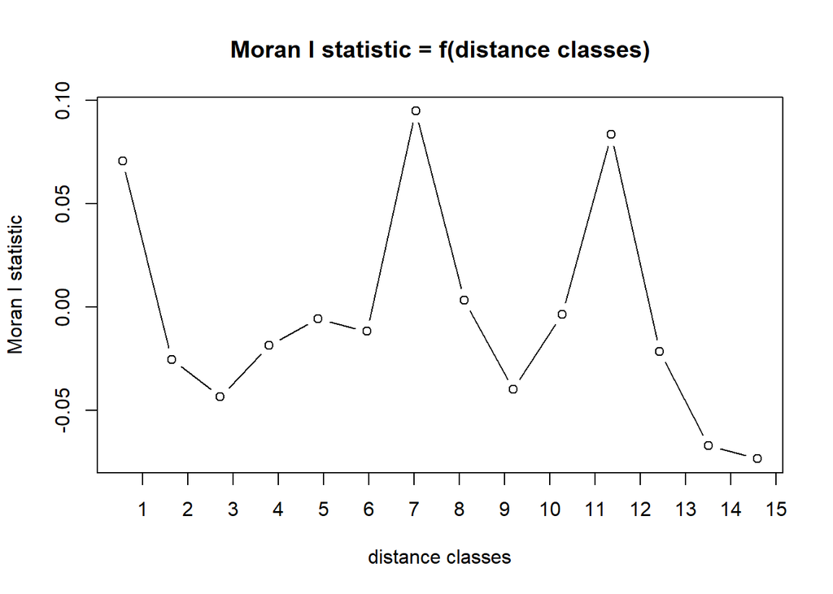

```r
plot(correl_napn2o_pg)
```

```r
# apply to SpatialPointsDataFrame that has projected coordinates and believe returning distance classes in meters
coords_sp_nap <- coordinates(nap_sp_visit1)
correl_spnapn2o_pg <- pgirmess::correlog(coords_sp_nap, log(nap_sp_visit1@data$dissolved_n2o_nmol), method = "Moran", nbclass = 30, alternative = "two.sided")

head(round(correl_spnapn2o_pg, 2), 30)
```

```
##       dist.class  coef p.value    n
##  [1,]   23934.86  0.12    0.14  298
##  [2,]   66995.87  0.06    0.24  654
##  [3,]  110056.88 -0.05    0.42  830
##  [4,]  153117.89 -0.04    0.56  968
##  [5,]  196178.89 -0.04    0.46  958
##  [6,]  239239.90 -0.01    0.98 1072
##  [7,]  282300.91 -0.01    0.95 1128
##  [8,]  325361.92 -0.02    0.81  926
##  [9,]  368422.93 -0.04    0.58  748
## [10,]  411483.94  0.01    0.65  624
## [11,]  454544.95  0.02    0.66  536
## [12,]  497605.96 -0.04    0.70  418
## [13,]  540666.97  0.01    0.72  396
## [14,]  583727.98 -0.06    0.59  276
```

[output cut: 16 more lines]

```r
tail(round(correl_spnapn2o_pg ,2))
```

```
##       dist.class  coef p.value  n
## [25,]    1057399  0.17    0.21 50
## [26,]    1100460 -0.14    0.71 32
## [27,]    1143521  0.04    0.56 44
## [28,]    1186582 -0.10    0.86 42
## [29,]    1229643 -0.12    0.93 12
## [30,]    1272704 -0.11    0.27  6
```

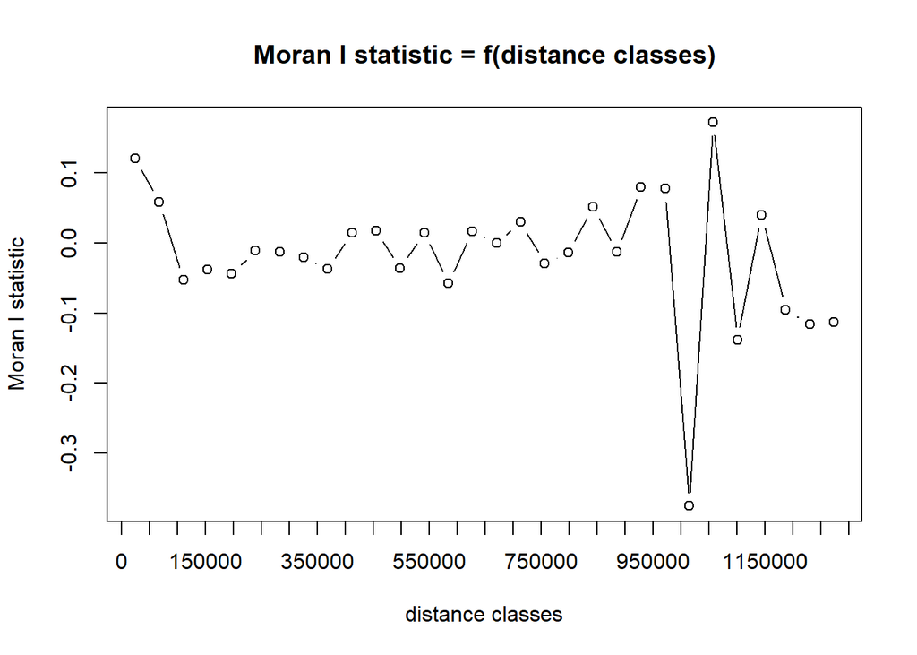

```r
plot(correl_spnapn2o_pg)
```

## 2.9 Correlograms by Ecoregions

Doug Anderson wrote functions to deal with the list of list output from the correlog function in the ncf package. He also wrote functions so that the correlogram of dissolved NO2 gas could be plotted by ecoregion using base plot, cowplot, or ggplot2 code.

```r
# Original code from Doug Anderson at Neptune from file:  Neptune_correlogram_TDS05_Anderson.Rmd

# set the theme of the ggplot
theme_set(theme_bw()) # the theme I prefer is theme_bw()

## Can define a new function to plot
plot_correlog <- function(ncf_correlog,
                          # names of list components
                          n_col = "n",
                          mean_col = "mean.of.class",
                          cor_col = "correlation",
                          xint_col = "x.intercept",
                          pval_col = "p",
                          name_col = NULL, #can change to column that has names of interest
                          alpha = 0.05, # two sided significance level
                          # plot labels and adjustments
                          plot_title = "Correlogram", #can change to NULL
                          plot_subtitle = waiver(),
                          y_label = "Correlation",
                          x_label = "Distance (mean-of-class)",
                          pt_size = I(2), pt_color = "black",
                          ln_size = I(0.5), ln_color = "black",
                          ln_type = "solid",
                          title_size = 14, subtitle_size = 14,
                          axis_title_size = 14, axis_text_size = 14,
                          title_color = "black",
                          subtitle_color = "black",
                          axis_title_color = "black",
                          axis_text_color = "black",
                          title_bold = TRUE, axis_bold = FALSE,
                          xaxis_color = "gray", xaxis_type = "solid",
                          theme_style = theme_bw()){
  # ncf_correlog is a list object exported from ncf::correlog() but can also be a dataframe with named columns

  # prepare a data set for plotting based on the list components or data frame columns
  dat <- data.frame(
    n = ncf_correlog[[n_col]],
    mean = ncf_correlog[[mean_col]],
    cor = ncf_correlog[[cor_col]],
    # xint = ncf_correlog[[xint_col]],
    pval = ncf_correlog[[pval_col]]
  )
  # create a variable to help plot the hollow and solid points
  # If a permutation test was performed, values significant at a nominal (two-sided) 5%-level
  # will be represented by filled circles and non-significant values by open circles.
  dat$sig <- ifelse(dat$pval * 2 < alpha, TRUE, FALSE)

  ## Start the plot
  g <- ggplot(dat) +
    theme_style +
    geom_hline(yintercept = 0, color = xaxis_color, linetype = xaxis_type) +
    # geom_point(aes(x=mean, y=cor, shape=sig), size=pt_size, color=pt_color) +
    # geom_line(aes(x=mean, y=cor, group=1), size=ln_size, color=ln_color, linetype=ln_type) +
    lemon::geom_pointline(aes(x=mean, y=cor, shape=sig, group=1),
                          size = pt_size, color = pt_color,
                          linetype = ln_type, linesize = ln_size,
                          linecolor = ln_color) +
    scale_shape_manual(values=c("TRUE"=19, "FALSE"=1),
                       labels=c("TRUE"="Sig.", "FALSE"="Not Sig."),
                       guide=FALSE) +
    labs(x=x_label, y=y_label)

  ## add a title
  if(!is.null(name_col)){#include a title if column for name is provided or list object has a list item for name
    if(!is.null(plot_title)){ #if plot_title is a string, separate the plot_title with the other name by a ':'
      nm <- unique(as.character(ncf_correlog[[name_col]]))
      g <- g +
        ggtitle(label = paste(plot_title, ": ", nm, sep=""), subtitle = plot_subtitle)
    } else{ #if plot_title is null, only include the name
      nm <- unique(as.character(ncf_correlog[[name_col]]))
      g <- g +
        ggtitle(label = nm, subtitle = plot_subtitle)
    }
  } else{ # if there is no name column, only include the plot_title of interest (can be NULL)
    g <- g +
      ggtitle(label = plot_title, subtitle = plot_subtitle)
  }

  ## modify theme
  g <- g +
    theme(plot.title = element_text(size=title_size,
                                    hjust=0.5, #change to a value between 0 (left) and 1 (right)
                                    face=ifelse(title_bold == TRUE, "bold", "plain"),
                                    color=title_color),
          plot.subtitle = element_text(size=subtitle_size,
                                       hjust=0.5,
                                       color=subtitle_color),
          axis.title = element_text(size=axis_title_size,
                                    face=ifelse(axis_bold == TRUE, "bold", "plain"),
                                    color=axis_title_color),
          axis.text = element_text(size=axis_text_size, #?theme
                                   color=axis_text_color), #?element_text
          panel.grid.major = element_blank(),
          panel.grid.minor = element_blank())
  return(g)
}

dg_1 <- select(dg,site.id:map.lon.dd, dissolved.n2o.nmol, WSA9, WSA9_NAME, ONOFFNET, nitrate.n.result,chla.result.vol, max.bf, temp.surf, temp.bottom, o2.surf, o2.bottom, lake.orgn, state, size.cat)
names(dg_1)
```

```
##  [1] "site.id"              "visit.no"             "sample.source"
##  [4] "date.col"             "n2o.ppm.gc_rpd"       "co2.ppm.gc_rpd"
##  [7] "co2.ppm.gc.adj_rpd"   "ch4.ppm.gc_rpd"       "dissolved.co2_rpd"
## [10] "dissolved.co2.jb_rpd" "dissolved.ch4_rpd"    "dissolved.n2o_rpd"
## [13] "co2.sat.ratio_rpd"    "ch4.sat.ratio_rpd"    "n2o.sat.ratio_rpd"
## [16] "map.lat.dd"           "map.lon.dd"           "dissolved.n2o.nmol"
## [19] "WSA9"                 "WSA9_NAME"            "ONOFFNET"
## [22] "nitrate.n.result"     "chla.result.vol"      "max.bf"
## [25] "temp.surf"            "temp.bottom"          "o2.surf"
## [28] "o2.bottom"            "lake.orgn"            "state"
## [31] "size.cat"
```

```r
dg_1 <- clean_names(dg_1)
names(dg_1)
```

```
##  [1] "site_id"              "visit_no"             "sample_source"
##  [4] "date_col"             "n2o_ppm_gc_rpd"       "co2_ppm_gc_rpd"
##  [7] "co2_ppm_gc_adj_rpd"   "ch4_ppm_gc_rpd"       "dissolved_co2_rpd"
## [10] "dissolved_co2_jb_rpd" "dissolved_ch4_rpd"    "dissolved_n2o_rpd"
## [13] "co2_sat_ratio_rpd"    "ch4_sat_ratio_rpd"    "n2o_sat_ratio_rpd"
## [16] "map_lat_dd"           "map_lon_dd"           "dissolved_n2o_nmol"
## [19] "wsa9"                 "wsa9_name"            "onoffnet"
## [22] "nitrate_n_result"     "chla_result_vol"      "max_bf"
## [25] "temp_surf"            "temp_bottom"          "o2_surf"
## [28] "o2_bottom"            "lake_orgn"            "state"
## [31] "size_cat"
```

```r
dg_1 <- dg_1 %>% mutate(log_n2o = round(log(dissolved_n2o_nmol),3))
## Subset dg_1 by visit_no == 1
dg_visit1 <- dg_1 %>% dplyr::filter(visit_no == 1)

## Perform the same test for each wsa9 using Z = "log_n2o"
## Start by defining a function
ncf_correlog <- function(dat, # data to send to ncf::correlog
                         z_col, # name of the column in the dataset for water quality parameter
                         i = 50, # increment to be used in ncf::correlog
                         N = 1000, # number of resamples in ncf::correlog
                         x_col = "map_lon_dd", # name of the column in the dataset for longitude
                         y_col = "map_lat_dd", # name of the column in the dataset for latitude
                         lat_lon = TRUE, # if the x and y coordinates for ncf::correlog are lat and lon
                         rem_missing = FALSE, # argument of ncf::correlog
                         run_quietly = FALSE){ # argument of ncf::correlog
  library(ncf)

  X = dat[[x_col]] #grabs the x_col from data.frame
  Y = dat[[y_col]] #grabs the y_col from data.frame
  Z = dat[[z_col]] #grabs the z_col from data.frame

  ## Use ncf::correlog
  crlg <- ncf::correlog(x = X, y = Y, z = Z,
                        increment = i, resamp = N, latlon = lat_lon,
                        na.rm = rem_missing, quiet = run_quietly)
  return(crlg)
}

## Split the dataframe by each wsa9: turns the data frame into a list
##   where each list item is a data frame filtered to that wsa9
## lapply applies the function ncf_correlog on each list object (a data frame)
## the final product is a list of correlog objects
## this is similar to looping
## setting seed so get same result from permutations ncf::correlog function
set.seed(2035)
log_n2o_correlog_list <- dg_visit1 %>%
  split(.$wsa9) %>% # '.' means use the data frame that preceded this line
  lapply(function(x) ncf_correlog(dat = x, z_col = "log_n2o"))
```

```
## 100  of  1000
200  of  1000
300  of  1000
400  of  1000
500  of  1000
600  of  1000
700  of  1000
800  of  1000
900  of  1000
1000  of  1000
100  of  1000
200  of  1000
300  of  1000
400  of  1000
500  of  1000
```

[output cut: 75 more lines]

```r
#ncf_correlog is the function name,
#dat is the paramater that takes a data.frame,
#z_col is the parameter that takes a string name for a column of a water quality paramater

## look at the structure: list of 9 items where each item is a
##   list containing 6 items: n, mean, correlation, x.int, p, call
str(log_n2o_correlog_list)
```

```
## List of 9
##  $ CPL:List of 6
##   ..$ n            : Named int [1:57] 71 157 205 240 266 237 254 279 281 246 ...
##   .. ..- attr(*, "names")= chr [1:57] "1" "2" "3" "4" ...
##   ..$ mean.of.class: Named num [1:57] 30.2 77 125.6 175.9 225 ...
##   .. ..- attr(*, "names")= chr [1:57] "1" "2" "3" "4" ...
##   ..$ correlation  : Named num [1:57] 1.47 0.294 0.206 0.159 0.188 ...
##   .. ..- attr(*, "names")= chr [1:57] "1" "2" "3" "4" ...
##   ..$ x.intercept  : Named num 481
##   .. ..- attr(*, "names")= chr "(Intercept)"
##   ..$ p            : num [1:57] 0.000999 0.001998 0.002997 0.010989 0.002997 ...
##   ..$ call         : chr [1:2] "ncf::correlog(x = X, y = Y, z = Z, increment = i, resamp = N, " "    latlon = lat_lon, na.rm = rem_missing, quiet = run_quietly)"
##   ..- attr(*, "class")= chr "correlog"
##  $ NAP:List of 6
##   ..$ n            : Named int [1:26] 181 417 510 550 595 660 546 416 340 291 ...
##   .. ..- attr(*, "names")= chr [1:26] "1" "2" "3" "4" ...
##   ..$ mean.of.class: Named num [1:26] 32.7 78.1 127.1 174.6 225.2 ...
##   .. ..- attr(*, "names")= chr [1:26] "1" "2" "3" "4" ...
##   ..$ correlation  : Named num [1:26] 0.2496 0.0483 -0.0401 0.0138 -0.0501 ...
##   .. ..- attr(*, "names")= chr [1:26] "1" "2" "3" "4" ...
##   ..$ x.intercept  : Named num 100
##   .. ..- attr(*, "names")= chr "(Intercept)"
##   ..$ p            : num [1:26] 0.000999 0.080919 0.215784 0.250749 0.11988 ...
##   ..$ call         : chr [1:2] "ncf::correlog(x = X, y = Y, z = Z, increment = i, resamp = N, " "    latlon = lat_lon, na.rm = rem_missing, quiet = run_quietly)"
##   ..- attr(*, "class")= chr "correlog"
##  $ NPL:List of 6
##   ..$ n            : Named int [1:27] 103 169 216 214 241 251 250 279 211 159 ...
##   .. ..- attr(*, "names")= chr [1:27] "1" "2" "3" "4" ...
##   ..$ mean.of.class: Named num [1:27] 28.7 75.6 126.5 173.6 225.7 ...
##   .. ..- attr(*, "names")= chr [1:27] "1" "2" "3" "4" ...
##   ..$ correlation  : Named num [1:27] -0.08757 -0.03657 -0.00143 -0.01778 -0.02282 ...
##   .. ..- attr(*, "names")= chr [1:27] "1" "2" "3" "4" ...
##   ..$ x.intercept  : num 0
##   ..$ p            : num [1:27] 0.147 0.314 0.417 0.437 0.392 ...
##   ..$ call         : chr [1:2] "ncf::correlog(x = X, y = Y, z = Z, increment = i, resamp = N, " "    latlon = lat_lon, na.rm = rem_missing, quiet = run_quietly)"
##   ..- attr(*, "class")= chr "correlog"
##  $ SAP:List of 6
##   ..$ n            : Named int [1:40] 82 149 226 246 303 280 377 381 379 365 ...
##   .. ..- attr(*, "names")= chr [1:40] "1" "2" "3" "4" ...
##   ..$ mean.of.class: Named num [1:40] 31.8 75.5 125.7 175.5 226.9 ...
```

[output cut: 51 more lines]

```
##   ..$ p            : num [1:43] 0.24476 0.00999 0.43556 0.005 0.27672 ...
##   ..$ call         : chr [1:2] "ncf::correlog(x = X, y = Y, z = Z, increment = i, resamp = N, " "    latlon = lat_lon, na.rm = rem_missing, quiet = run_quietly)"
##   ..- attr(*, "class")= chr "correlog"
##  $ XER:List of 6
##   ..$ n            : Named int [1:51] 20 58 90 93 89 109 108 105 107 118 ...
##   .. ..- attr(*, "names")= chr [1:51] "1" "2" "3" "4" ...
##   ..$ mean.of.class: Named num [1:51] 29.4 77.9 127.1 174.6 224.6 ...
##   .. ..- attr(*, "names")= chr [1:51] "1" "2" "3" "4" ...
##   ..$ correlation  : Named num [1:51] 0.5235 -0.0371 -0.0461 0.0292 -0.2389 ...
##   .. ..- attr(*, "names")= chr [1:51] "1" "2" "3" "4" ...
##   ..$ x.intercept  : Named num 32.6
##   .. ..- attr(*, "names")= chr "(Intercept)"
##   ..$ p            : num [1:51] 0.02697 0.43956 0.38561 0.30969 0.00999 ...
##   ..$ call         : chr [1:2] "ncf::correlog(x = X, y = Y, z = Z, increment = i, resamp = N, " "    latlon = lat_lon, na.rm = rem_missing, quiet = run_quietly)"
##   ..- attr(*, "class")= chr "correlog"
```

```r
## Function to remove the list item 'call' which is of a different length
##   than the other items (n, mean, correlation, x.int, and p)
## This function will also convert each list item to a dataframe
crlg_to_dat <- function(ncf_correlog, # ncf_correlog is a list object that was output from ncf::correlog
                        n_col = "n",
                        mean_col = "mean.of.class",
                        cor_col = "correlation",
                        xint_col = "x.intercept",
                        pval_col = "p"){
  dat <- data.frame(
    n = ncf_correlog[[n_col]],
    mean = ncf_correlog[[mean_col]],
    cor = ncf_correlog[[cor_col]],
    xint = ncf_correlog[[xint_col]],
    pval = ncf_correlog[[pval_col]]
  )
  return(dat)
}

## log_n20_correlog_list is already a list so there is no need to split
log_n2o_correlog_dats <- lapply(log_n2o_correlog_list,
                                function(x) crlg_to_dat(ncf_correlog = x))
str(log_n2o_correlog_dats) # each item in the list is now a dataframe
```

```
## List of 9
##  $ CPL:'data.frame': 57 obs. of  5 variables:
##   ..$ n   : int [1:57] 71 157 205 240 266 237 254 279 281 246 ...
##   ..$ mean: num [1:57] 30.2 77 125.6 175.9 225 ...
##   ..$ cor : num [1:57] 1.47 0.294 0.206 0.159 0.188 ...
##   ..$ xint: num [1:57] 481 481 481 481 481 ...
##   ..$ pval: num [1:57] 0.000999 0.001998 0.002997 0.010989 0.002997 ...
##  $ NAP:'data.frame': 26 obs. of  5 variables:
##   ..$ n   : int [1:26] 181 417 510 550 595 660 546 416 340 291 ...
##   ..$ mean: num [1:26] 32.7 78.1 127.1 174.6 225.2 ...
##   ..$ cor : num [1:26] 0.2496 0.0483 -0.0401 0.0138 -0.0501 ...
##   ..$ xint: num [1:26] 100 100 100 100 100 ...
##   ..$ pval: num [1:26] 0.000999 0.080919 0.215784 0.250749 0.11988 ...
##  $ NPL:'data.frame': 27 obs. of  5 variables:
##   ..$ n   : int [1:27] 103 169 216 214 241 251 250 279 211 159 ...
##   ..$ mean: num [1:27] 28.7 75.6 126.5 173.6 225.7 ...
##   ..$ cor : num [1:27] -0.08757 -0.03657 -0.00143 -0.01778 -0.02282 ...
##   ..$ xint: num [1:27] 0 0 0 0 0 0 0 0 0 0 ...
##   ..$ pval: num [1:27] 0.147 0.314 0.417 0.437 0.392 ...
##  $ SAP:'data.frame': 40 obs. of  5 variables:
##   ..$ n   : int [1:40] 82 149 226 246 303 280 377 381 379 365 ...
##   ..$ mean: num [1:40] 31.8 75.5 125.7 175.5 226.9 ...
##   ..$ cor : num [1:40] 0.19475 -0.00831 0.04536 0.08559 -0.07662 ...
##   ..$ xint: num [1:40] 33.6 33.6 33.6 33.6 33.6 ...
##   ..$ pval: num [1:40] 0.036 0.4865 0.1848 0.0579 0.0879 ...
##  $ SPL:'data.frame': 31 obs. of  5 variables:
##   ..$ n   : int [1:31] 91 149 175 236 233 219 222 199 248 222 ...
##   ..$ mean: num [1:31] 27 77.7 125.5 175.8 226 ...
##   ..$ cor : num [1:31] -0.0113 -0.0522 0.1148 -0.0291 0.0449 ...
##   ..$ xint: num [1:31] 0 0 0 0 0 0 0 0 0 0 ...
##   ..$ pval: num [1:31] 0.5 0.261 0.043 0.357 0.161 ...
##  $ TPL:'data.frame': 37 obs. of  5 variables:
##   ..$ n   : int [1:37] 177 308 379 402 510 520 529 566 638 617 ...
##   ..$ mean: num [1:37] 29.9 76.1 125 176.3 226.1 ...
##   ..$ cor : num [1:37] 0.2618 0.1714 0.0673 0.0678 0.015 ...
##   ..$ xint: num [1:37] 268 268 268 268 268 ...
##   ..$ pval: num [1:37] 0.003 0.002 0.0869 0.0679 0.3027 ...
##  $ UMW:'data.frame': 23 obs. of  5 variables:
##   ..$ n   : int [1:23] 353 640 816 916 1051 1031 870 830 715 764 ...
##   ..$ mean: num [1:23] 30.5 76.3 125.7 175.1 225.4 ...
##   ..$ cor : num [1:23] 0.1925 0.2105 0.0311 0.0313 -0.0297 ...
##   ..$ xint: num [1:23] 200 200 200 200 200 ...
##   ..$ pval: num [1:23] 0.003996 0.000999 0.107892 0.096903 0.190809 ...
##  $ WMT:'data.frame': 43 obs. of  5 variables:
##   ..$ n   : int [1:43] 140 235 310 267 269 315 367 420 498 530 ...
##   ..$ mean: num [1:43] 27.4 74.2 126.2 174.4 225.3 ...
##   ..$ cor : num [1:43] -0.060554 -0.152092 -0.000749 0.160099 -0.041011 ...
##   ..$ xint: num [1:43] 0 0 0 0 0 0 0 0 0 0 ...
##   ..$ pval: num [1:43] 0.24476 0.00999 0.43556 0.005 0.27672 ...
##  $ XER:'data.frame': 51 obs. of  5 variables:
##   ..$ n   : int [1:51] 20 58 90 93 89 109 108 105 107 118 ...
##   ..$ mean: num [1:51] 29.4 77.9 127.1 174.6 224.6 ...
##   ..$ cor : num [1:51] 0.5235 -0.0371 -0.0461 0.0292 -0.2389 ...
##   ..$ xint: num [1:51] 32.6 32.6 32.6 32.6 32.6 ...
##   ..$ pval: num [1:51] 0.02697 0.43956 0.38561 0.30969 0.00999 ...
```

```r
## combine into one dataframe to grab the wsa9 (notice the name no longer has an s at the end)

log_n2o_correlog_dat <- log_n2o_correlog_dats %>%
  dplyr::bind_rows(., .id = "wsa9")

str(log_n2o_correlog_dat)
```

```
## 'data.frame':    335 obs. of  6 variables:
##  $ wsa9: chr  "CPL" "CPL" "CPL" "CPL" ...
##  $ n   : int  71 157 205 240 266 237 254 279 281 246 ...
##  $ mean: num  30.2 77 125.6 175.9 225 ...
##  $ cor : num  1.47 0.294 0.206 0.159 0.188 ...
##  $ xint: num  481 481 481 481 481 ...
##  $ pval: num  0.000999 0.001998 0.002997 0.010989 0.002997 ...
```

```r
head(log_n2o_correlog_dat)
```

|  | wsa9 | n | mean | cor | xint | pval |
| --- | --- | --- | --- | --- | --- | --- |
| 1...1 | CPL | 71 | 30.21935 | 1.4701804 | 481.0026 | 0.000999001 |
| 2...2 | CPL | 157 | 77.03206 | 0.2944234 | 481.0026 | 0.001998002 |
| 3...3 | CPL | 205 | 125.64867 | 0.2063462 | 481.0026 | 0.002997003 |
| 4...4 | CPL | 240 | 175.85189 | 0.1591291 | 481.0026 | 0.010989011 |
| 5...5 | CPL | 266 | 224.98428 | 0.1877982 | 481.0026 | 0.002997003 |
| 6...6 | CPL | 237 | 275.16273 | 0.0321398 | 481.0026 | 0.258741259 |

```r
## Make individual plots, the following object is a list containing a ggplot for each
log_n2o_correlog_plots <- log_n2o_correlog_dat %>%
  split(.$wsa9) %>% # splits the data frame by wsa9, which creates a list with 9 data frames
  lapply(function(x) plot_correlog(ncf_correlog = x, # use the data.frame for each wsa9 to make a plot
                                   plot_title = NULL,
                                   n_col = "n",
                                   mean_col = "mean",
                                   cor_col = "cor",
                                   xint_col = "xint",
                                   pval_col = "pval",
                                   name_col = "wsa9",
                                   title_size = 14,
                                   subtitle_size = 14,
                                   axis_title_size = 14,
                                   axis_text_size = 14))
## if hard to see writing run again but increase "title_size", "subtitle_size", "axis_title_size", "axis_text_size" as needed

## Look at each piece individually or scroll through
length(log_n2o_correlog_plots) # shows 9 items
```

```
## [1] 9
```

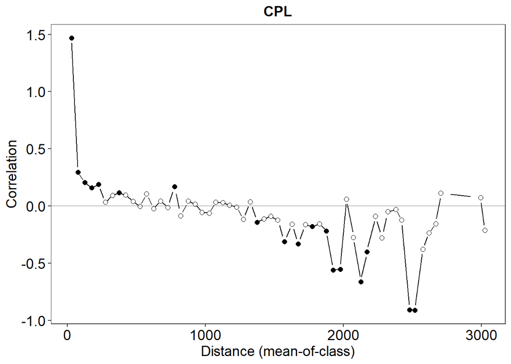

```r
# log_n20_correlog_plots
log_n2o_correlog_plots$CPL #or log_n20_correlog_plots[["CPL"]] or log_n2o_correlog_plots[[1]]
```

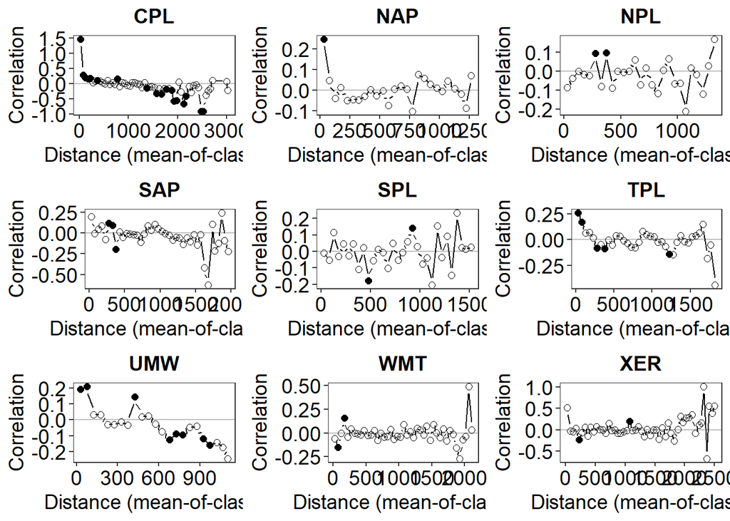

```r
# log_n2o_correlog_plots$NAP
# log_n2o_correlog_plots$NPL
# log_n2o_correlog_plots$SAP
# log_n2o_correlog_plots$SPL
# log_n2o_correlog_plots$TPL
# log_n2o_correlog_plots$UMW
# log_n2o_correlog_plots$WMT
# log_n2o_correlog_plots$XER

## cowplot package (or other) can be used to group them into a matrix plot
log_n2o_correlog_plotgrid <-
  cowplot::plot_grid(plotlist=log_n2o_correlog_plots, ncol=3)
print(log_n2o_correlog_plotgrid) # click 'Zoom' in plots quadrant, takes a few seconds to render
```

```r
## can save the plot using
# cowplot::ggsave(filename = "FILENAME.png", #saves a png version of the figure to the working folder
#                 plot = log_n20_correlog_plotgrid)
## can change .png to other forms
## can play with scale, width, and height to adjust the output of the figure saved to the png file

## alternatively, can make a facet plot since log_n20_correlog_dat is a dataframe in the correct format
names(log_n2o_correlog_dat) #"n"    "mean" "cor"  "xint" "pval" "wsa9"
```

```
## [1] "wsa9" "n"    "mean" "cor"  "xint" "pval"
```

```r
## create column to shape point, sig == TRUE means two-sided test < 0.05
log_n2o_correlog_dat$sig <- ifelse(log_n2o_correlog_dat$pval * 2 < 0.05,
                                   TRUE, FALSE)
head(log_n2o_correlog_dat)
```

|  | wsa9 | n | mean | cor | xint | pval | sig |
| --- | --- | --- | --- | --- | --- | --- | --- |
| 1...1 | CPL | 71 | 30.21935 | 1.4701804 | 481.0026 | 0.000999001 | TRUE |
| 2...2 | CPL | 157 | 77.03206 | 0.2944234 | 481.0026 | 0.001998002 | TRUE |
| 3...3 | CPL | 205 | 125.64867 | 0.2063462 | 481.0026 | 0.002997003 | TRUE |
| 4...4 | CPL | 240 | 175.85189 | 0.1591291 | 481.0026 | 0.010989011 | TRUE |
| 5...5 | CPL | 266 | 224.98428 | 0.1877982 | 481.0026 | 0.002997003 | TRUE |
| 6...6 | CPL | 237 | 275.16273 | 0.0321398 | 481.0026 | 0.258741259 | FALSE |

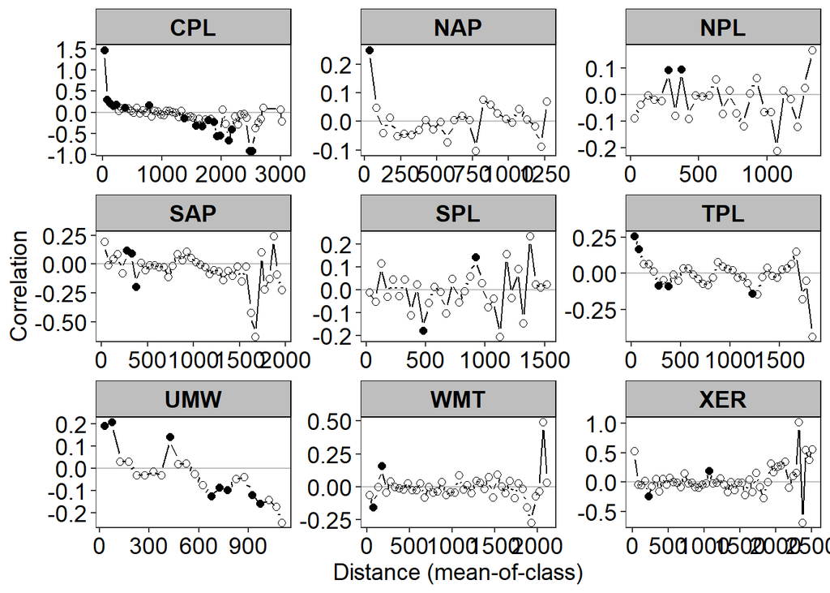

```r
## can change wsa9 to a factor to arrange what order the plots are shown, otherwise default arranges them alphabetically
# log_n20_correlog_dat$wsa9 <- factor(log_n20_correlog_dat,
#                                     levels = c("CPL", "NAP", "NPL", "SAP", "SPL", "TPL", "UMW", "WMT", "XER"))

## make facet plot
log_n2o_correlog_facetplot <- ggplot(log_n2o_correlog_dat) +
  geom_hline(yintercept = 0, color = "gray", linetype = "solid") +
  # geom_point(aes(x=mean, y=cor, shape=sig), size=I(2), color="black") +
  # geom_line(aes(x=mean, y=cor, group=1), size=I(0.5), color="black", linetype="solid") +
  lemon::geom_pointline(aes(x=mean, y=cor, shape=sig, group=1),
                        size=I(2), color = "black",
                        linetype = "solid", linesize = I(0.5),
                        linecolor = "black") +
  scale_shape_manual(values=c("TRUE"=19, "FALSE"=1),
                     labels=c("TRUE"="Sig.", "FALSE"="Not Sig."),
                     guide=FALSE) +
  facet_wrap(~wsa9, ncol=3, scales="free") +
  labs(x="Distance (mean-of-class)", y="Correlation") +
  theme_bw() +
  theme(plot.title = element_text(size=14, hjust=0.5,
                                  face="bold", color="black"),
        plot.subtitle = element_text(size=14, hjust=0.5, color="black"),
        axis.title = element_text(size=14, face="plain", color="black"),
        axis.text = element_text(size=14, color="black"),
        strip.text = element_text(size=14, color="black", face="bold"),
        strip.background = element_rect(fill="gray", color="black"),
        panel.grid.major = element_blank(),
        panel.grid.minor = element_blank())
print(log_n2o_correlog_facetplot)
```

```r
## can save the plot using
# cowplot::ggsave(filename = "FILENAME2.png", #saves a png version of the figure to the working folder
#                 plot = log_n20_correlog_facetplot)
## can change .png to other forms
## can play with scale, width, and height to adjust the output of the figure saved to the png file
```

## 2.10 Semivariograms

Variograms display the variability among pairs of points at various separation distances. I was unable to fit a model to the dissolved gas concentration variograms using the default fitting parameters in gstat. The variograms suggest a lack of spatial structure, but I suspect the model parameterization can be improved.

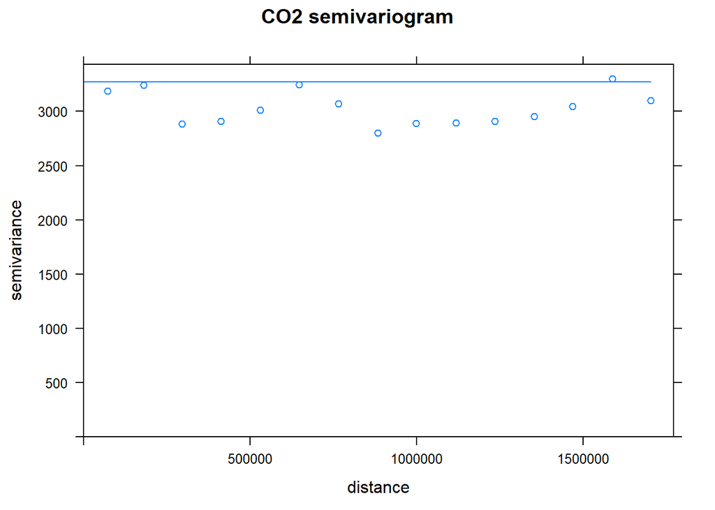

```r
# Variogram function requires sp object
dg.sp <- as(dg.sf, Class = "Spatial")

# CO2 variogram
co2.v <- variogram(dissolved.co2.umol~1, dg.sp)
co2.v.fit <- fit.variogram(co2.v, vgm(c("Exp", "Mat", "Sph"))) # allow to choose best model.  Not sure which model warnings are associated with.
# co2.v.fit # chose sperical
co2.v.fit <- fit.variogram(co2.v, vgm("Sph")) # refit spherical, several warnings (?)

# CH4 variogram
ch4.v <- variogram(dissolved.ch4.umol~1, dg.sp)
ch4.v.fit <- fit.variogram(ch4.v, vgm(c("Exp", "Mat", "Sph"))) # allow to choose best model.  Not sure which model warnings are associated with.
# ch4.v.fit # chose exp
ch4.v.fit <- fit.variogram(ch4.v, vgm("Exp")) # refit exponential, no convergence

# N2O variogram
n2o.v <- variogram(dissolved.n2o.nmol~1, dg.sp)
n2o.v.fit <- fit.variogram(n2o.v, vgm(c("Exp", "Mat", "Sph"))) # allow to choose best model.  Not sure which model warnings are associated with.
# n2o.v.fit # chose exp
n2o.v.fit <- fit.variogram(n2o.v, vgm("Exp")) # refit exponential, no convergence


# Plot variograms and models (if fit)
plot(co2.v, model = co2.v.fit, main = "CO2 semivariogram")
```

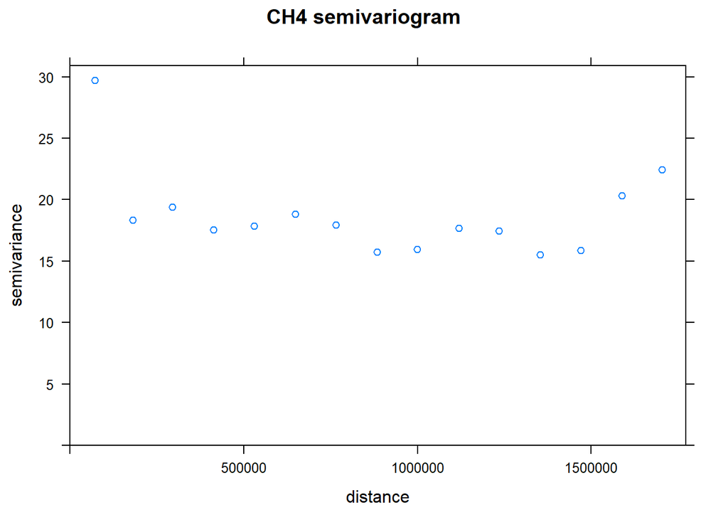

```r
plot(ch4.v, main = "CH4 semivariogram")
```

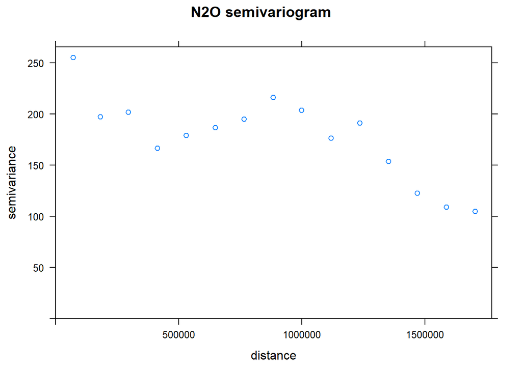

```r
plot(n2o.v, main = "N2O semivariogram")
```

## 2.11 Random Semivariograms

The empirical semivariogram for surface dissolved oxygen is approximately a horizontal line, showing no evidence of spatial autocorrelation.

```r
names(dg)
```

```
##   [1] "site.id"                   "visit.no"
##   [3] "sample.source"             "date.col"
##   [5] "n2o.ppm.gc_rpd"            "co2.ppm.gc_rpd"
##   [7] "co2.ppm.gc.adj_rpd"        "ch4.ppm.gc_rpd"
##   [9] "dissolved.co2_rpd"         "dissolved.co2.jb_rpd"
##  [11] "dissolved.ch4_rpd"         "dissolved.n2o_rpd"
##  [13] "co2.sat.ratio_rpd"         "ch4.sat.ratio_rpd"
##  [15] "n2o.sat.ratio_rpd"         "map.lat.dd"
##  [17] "map.lon.dd"                "n2o.ppm.gc"
##  [19] "co2.ppm.gc"                "co2.ppm.gc.adj"
##  [21] "ch4.ppm.gc"                "bp.kPa"
##  [23] "headtemp"                  "surftemp"
##  [25] "dissolved.co2.jb"          "co2.sat.ratio"
##  [27] "ch4.sat.ratio"             "n2o.sat.ratio"
##  [29] "co2.ppm.iso_rpd"           "ch4.ppm.iso_rpd"
```

[output cut: 183 more lines]

```r
dg_1 <- clean_names(dg)
# also includ WSA9, WSA9_NAME feature plus variables from Jake's 02/25/2020 email
# added ntl.lab.result, ptl.lab.result on 06/18/2020
# added physical variables, temperature and depth, on 06/23/2020
# added silica and calcium based on Leon-Palmero 2020 paper 06/24/2020
# made nitrate_n_result into binary variable nitrate_n_b b/c 1/4th of observation have 0.000 value 06/25/2020
# added ph_result 12/14/2020
names(dg_1)
```

```
##   [1] "site_id"                         "visit_no"
##   [3] "sample_source"                   "date_col"
##   [5] "n2o_ppm_gc_rpd"                  "co2_ppm_gc_rpd"
##   [7] "co2_ppm_gc_adj_rpd"              "ch4_ppm_gc_rpd"
##   [9] "dissolved_co2_rpd"               "dissolved_co2_jb_rpd"
##  [11] "dissolved_ch4_rpd"               "dissolved_n2o_rpd"
##  [13] "co2_sat_ratio_rpd"               "ch4_sat_ratio_rpd"
##  [15] "n2o_sat_ratio_rpd"               "map_lat_dd"
##  [17] "map_lon_dd"                      "n2o_ppm_gc"
##  [19] "co2_ppm_gc"                      "co2_ppm_gc_adj"
##  [21] "ch4_ppm_gc"                      "bp_k_pa"
##  [23] "headtemp"                        "surftemp"
##  [25] "dissolved_co2_jb"                "co2_sat_ratio"
##  [27] "ch4_sat_ratio"                   "n2o_sat_ratio"
##  [29] "co2_ppm_iso_rpd"                 "ch4_ppm_iso_rpd"
```

[output cut: 183 more lines]

```r
dg_1 <- select(dg_1,site_id:date_col, map_lat_dd, map_lon_dd, dissolved_co2_umol, dissolved_ch4_umol, dissolved_n2o_nmol, co2_sat_ratio, ch4_sat_ratio, n2o_sat_ratio, wsa9, wsa9_name, onoffnet, nitrate_n_result, chla_result_vol, ntl_lab_result, ph_result, ptl_lab_result,max_bf, temp_surf, temp_bottom, o2_surf, o2_bottom, lake_orgn, state, size_cat, silica_result, calcium_result, visit_no) %>% filter(visit_no == 1 & wsa9 != "AK")

names(dg_1)
```

```
##  [1] "site_id"            "visit_no"           "sample_source"
##  [4] "date_col"           "map_lat_dd"         "map_lon_dd"
##  [7] "dissolved_co2_umol" "dissolved_ch4_umol" "dissolved_n2o_nmol"
## [10] "co2_sat_ratio"      "ch4_sat_ratio"      "n2o_sat_ratio"
## [13] "wsa9"               "wsa9_name"          "onoffnet"
## [16] "nitrate_n_result"   "chla_result_vol"    "ntl_lab_result"
## [19] "ph_result"          "ptl_lab_result"     "max_bf"
## [22] "temp_surf"          "temp_bottom"        "o2_surf"
## [25] "o2_bottom"          "lake_orgn"          "state"
## [28] "size_cat"           "silica_result"      "calcium_result"
```

```r
#filter in View returns 514 nitrate_n_result equal to zero
dg_1 <- dg_1 %>% mutate(log_n2o = round(log(dissolved_n2o_nmol),3)) %>%
  mutate(log_ntl = round(log(ntl_lab_result),3)) %>%
  mutate(log_ptl = round(log(ptl_lab_result),3)) %>%
  mutate(log_chla = round(log(chla_result_vol),1)) %>%
  mutate(log_si = round(log(silica_result),2)) %>%
  mutate(log_ca = round(log(calcium_result),2)) %>%
  mutate(ph_result = round(ph_result,2)) %>%
  mutate(nitrate_n_b = case_when(
    nitrate_n_result <= 0.0001 ~ "low",
    nitrate_n_result > 0.0001 ~ "high"))

dg_1$nitrate_n_b <- factor(dg_1$nitrate_n_b, levels = c("low", "high"))
summary(dg_1$nitrate_n_b)
```

```
##  low high
##  534  555
```

```r
# To enable spatial analysis of the data, the dataframe will be converted to a 'simple features' (sf) object.
# Define coordinates
coords <- data.frame(longitude = dg_1$map_lon_dd, latitude = dg_1$map_lat_dd)

dg_sf1 <- st_as_sf(dg_1, coords = c("map_lon_dd", "map_lat_dd"),
                  crs = 4269) %>% # standard for lat/lon
  st_transform(5070) # project to CONUS ALBERS for plotting

st_crs(dg_sf1)
```

[output not shown]

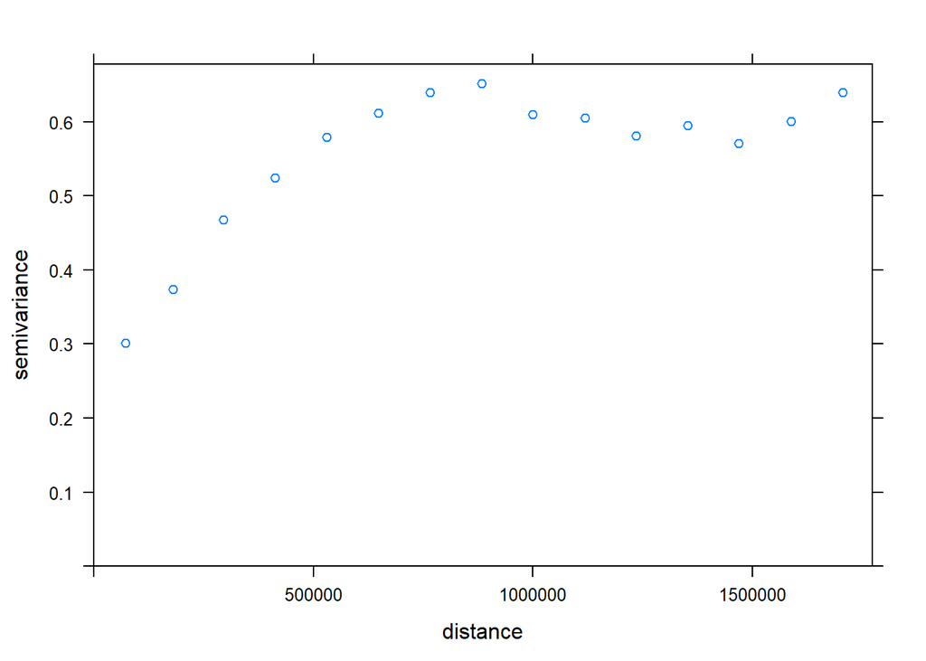

```r
z_ph_sf1 = variogram(ph_result~1, dg_sf1)
plot(z_ph_sf1)
```

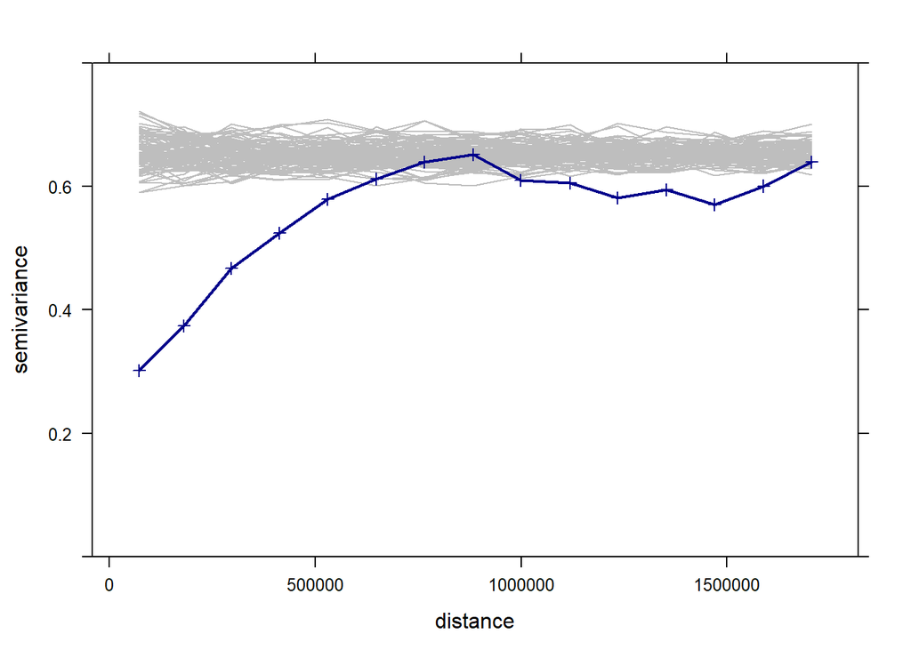

```r
# plot(z_ph_sf1, plot.numbers = TRUE)
# plot(z_ph_sf1, ylab = "NLA ph Semivariance")
# plot(z_ph_sf1, cex = 0.5, type = "b", pch = 20, asp = 1, xlab = "Distance (meters)", ylab = "NLA ph semivariance")
# z_ph_plot1 <- plot(z_ph_sf1, cex = 0.5, type = "b", pch = 20, asp = 1, xlab = "Distance (meters) ")

print(xyplot(gamma ~ dist, z_ph_sf1, pch = 3, type = 'b', lwd = 2, col = 'darkblue',
             panel = function(x, y, ...) {
                 for (i in 1:100) {
                     dg_sf1$random = sample(dg_sf1$ph_result)
                     v = variogram(random ~ 1, dg_sf1)
                     llines(v$dist, v$gamma, col = 'grey')
                 }
                 panel.xyplot(x, y, ...)
             },
             ylim = c(0, 0.8), xlab = 'distance', ylab = 'semivariance'
))
```

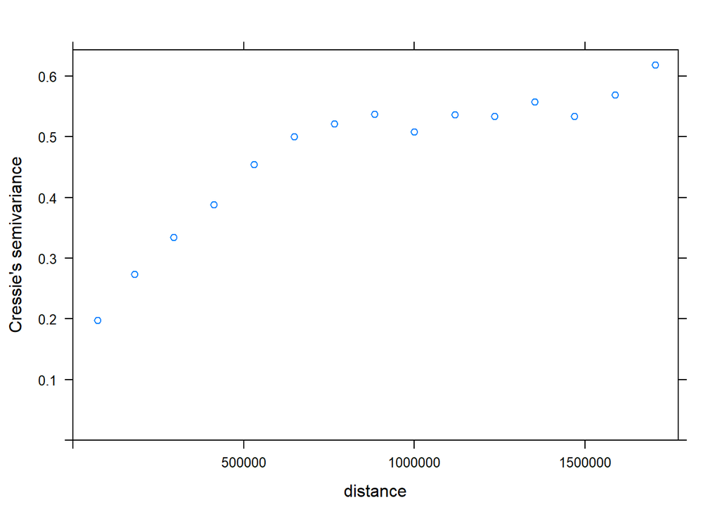

```r
z_cressie_ph <- variogram(ph_result~1, dg_sf1, cressie = TRUE)
plot(variogram(ph_result~1, dg_sf1, cressie = TRUE))
```

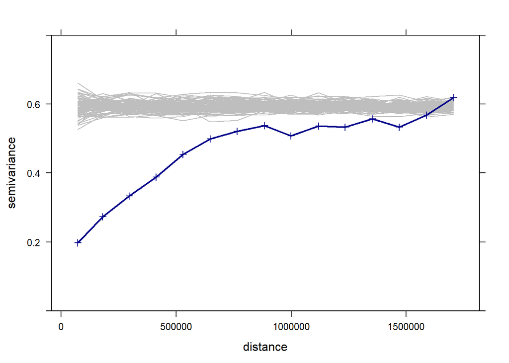

```r
print(xyplot(gamma ~ dist, z_cressie_ph, pch = 3, type = 'b', lwd = 2, col = 'darkblue',
             panel = function(x, y, ...) {
                 for (i in 1:100) {
                     dg_sf1$random = sample(dg_sf1$ph_result)
                     v = variogram(random ~ 1, dg_sf1, cressie = TRUE)
                     llines(v$dist, v$gamma, col = 'grey')
                 }
                 panel.xyplot(x, y, ...)
             },
             ylim = c(0, 0.8), xlab = 'distance', ylab = 'semivariance'
))
```

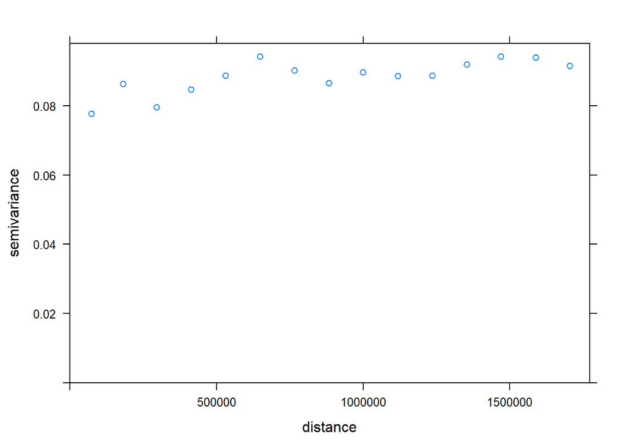

```r
z_do_sf1 = filter(dg_sf1, (!is.na(o2_surf))) %>% variogram(log(o2_surf)~1, .)
plot(z_do_sf1)
```

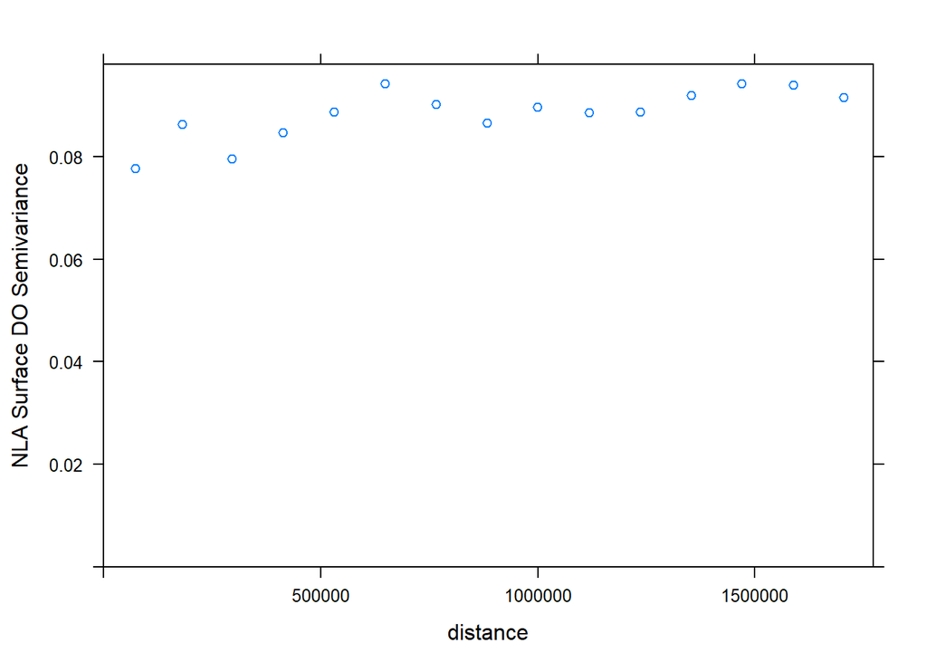

```r
# plot(z_ph_sf1, plot.numbers = TRUE)
plot(z_do_sf1, ylab = "NLA Surface DO Semivariance")
```

# 3 Exploratory analysis of N2O data

There are several sources of N2O in surface waters. The overlying atmosphere contains trace quantities of N2O (~300 ppb) that dissolve into surface waters as a function of barometric pressure and water temperature. N2O is also produced and consumed in aquatic ecosystems via denitrification. Denitrification is the reduction of oxidized forms of N (i.e. NO3) to more reduced forms (i.e. N2). It is a form of anaerobic respiration where oxidized forms of N serve as the electron acceptor in the absence of more energetically favorable alternatives, such as oxygen. N2O concentrations/fluxes are therefore somewhat dependent upon the availability of oxidized N and low dissolved oxygen. N2O can also be produced via nitrification. Nitrification is the aerobic oxidation of NH4 to more oxidized forms. N2O can be produced as a byproduct during the process and rates are somewhat dependent upon the availability of ammonium. See Beaulieu et al. 2011, 2014, and 2015 for more information.

The effect of denitrification and nitrification on dissolved N2O concentrations near the air-water interface is somewhat mediated by hydrology. Denitrification is an anaerobic process that occurs predominantly in the sediment or anoxic hypolimnion. Therefore, N2O must advect or diffuse from the sediment/hyoplimion to the water surface before it can affect dissolved N2O concentration near the air/water interface (where NLA samples were collected). Previous invesitgations have interpretted correlations between N2O and lake size and degree of thermal stratification as indicative of hydrologic control (DelSontro et al. 2019, Webb et al. 2019).

DelSontrol et al. (2019) reported that N2O emission rates were positively related to chl a. The authors (inlcuding me, I’m one of the ‘authors’!) speculate that chla is a surrogate for labile carbon. Denitrification requires carbon, so perhaps high rates of denitrification-N2O production occur in the presence of abundant carbon availability.

We do not yet have depth profiles of DO or temperature. When these data become available, we can include bottom water DO and strength of thermal stratification in the model. For now, we can explore correlations with the following variables.

- MeanDUsed - mean depth
- ph.result - pH
- nitrate.n.result - NO3-N (mg/L)
- ntl.lab.result - total nitrogen (mg/L)
- chla.result.vol - chlorophyll a (ug/L)
- ptl.lab.result - total phosphorus (mg/L)
- surftemp - surface water temperature (C)

A correlation matrix of dissolved N2O concentration and potential controlling variables doesn’t show any striking relationships, though the strongest relationship is with nitrate.

```r
library(corrr)
dg %>%
  select(dissolved.n2o.nmol, MeanDUsed, ph.result, nitrate.n.result, ntl.lab.result, chla.result.vol, ptl.lab.result, surftemp) %>%
  correlate()
```

```
##
## Correlation method: 'pearson'
## Missing treated using: 'pairwise.complete.obs'
```

| rowname | dissolved.n2o.nmol | MeanDUsed | ph.result | nitrate.n.result | ntl.lab.result | chla.result.vol | ptl.lab.result | surftemp |
| --- | --- | --- | --- | --- | --- | --- | --- | --- |
| dissolved.n2o.nmol | NA | -0.18638910 | 0.02254028 | 0.263884225 | 0.14770981 | 0.021119122 | 0.018514980 | -0.003198016 |
| MeanDUsed | -0.186389099 | NA | -0.04576722 | -0.058225621 | -0.05040949 | -0.072397902 | -0.045683152 | -0.111573941 |
| ph.result | 0.022540278 | -0.04576722 | NA | 0.050590909 | 0.35082026 | 0.130921384 | 0.199329666 | 0.036647812 |
| nitrate.n.result | 0.263884225 | -0.05822562 | 0.05059091 | NA | 0.63642389 | 0.002721961 | 0.008152604 | 0.015913505 |
| ntl.lab.result | 0.147709807 | -0.05040949 | 0.35082026 | 0.636423890 | NA | 0.455480363 | 0.470472951 | 0.039410391 |
| chla.result.vol | 0.021119122 | -0.07239790 | 0.13092138 | 0.002721961 | 0.45548036 | NA | 0.837262873 | 0.079883430 |
| ptl.lab.result | 0.018514980 | -0.04568315 | 0.19932967 | 0.008152604 | 0.47047295 | 0.837262873 | NA | 0.012976065 |
| surftemp | -0.003198016 | -0.11157394 | 0.03664781 | 0.015913505 | 0.03941039 | 0.079883430 | 0.012976065 | NA |

Categorization and regression analysis (CART), which can accomodate non-linear and interactive relationships, also identified nitrate as the most important predictor variable. The CART analysis did not identify splits associated with ecoregion.

```r
library(tree)
model <- tree(dissolved.n2o.nmol ~ MeanDUsed + nitrate.n.result + ntl.lab.result + chla.result.vol + ptl.lab.result + surftemp + WSA9, data = dg)
```

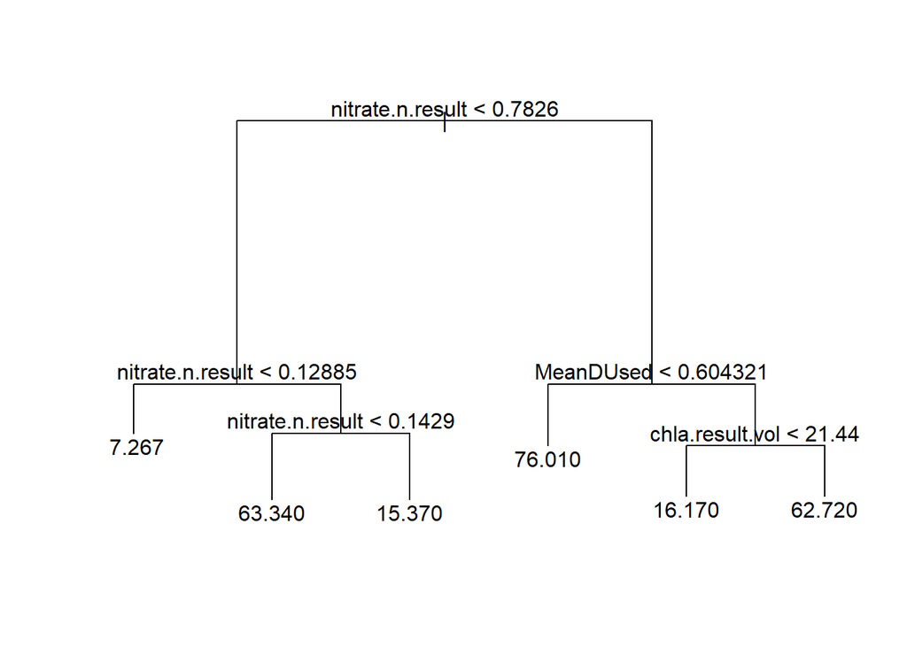

```r
plot(model)
text(model)
```